# Homework 11 - Machine learning essentials

Shuang Du

04/13/2022

# Use of `caret` with various methods

Run three machine learning models over the following training dataset with features `x` and labels `y`. You can use default tuning, e.g. bootstrap based resampling for tuning, as set by `trainControl`.

- SVM with radial kernel `"svmRadial"`
- Random forest `"rf"`
- Gradient boosting machine `"gbm"` (use `verbose=FALSE`)

Record the time to train, and the best Kappa value for each method over the tuning grid (`rf` does not use tuning parameters via `train` for this dataset). Which method obtains the best Kappa?

Finally, make a `pointrange` plot (see `geom_pointrange`), with the optimal Kappa and the SD for the optimal Kappa. Is there a clear winner, or all the methods mostly overlapping?

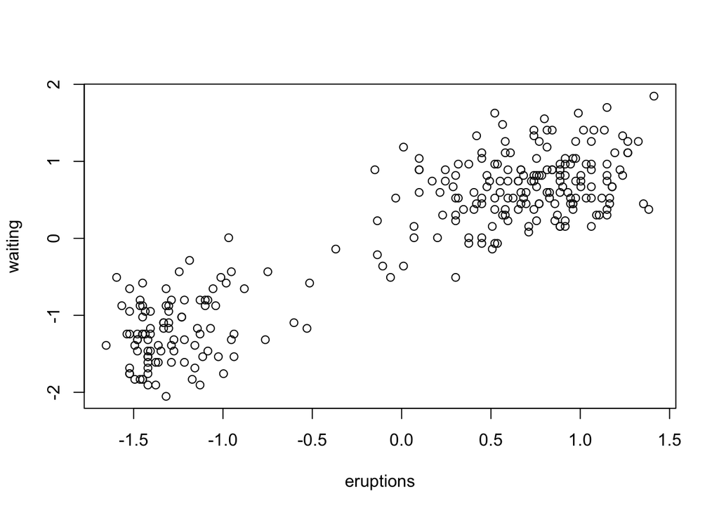

```r
data(faithful)
n <- nrow(faithful)
faithful <- data.frame(lapply(faithful, scale))
plot(faithful)
```

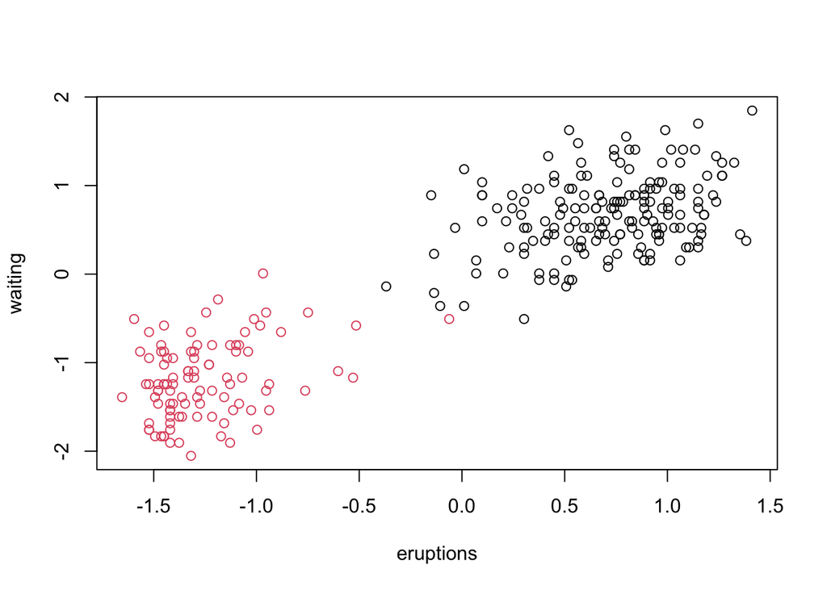

```r
faithful$cl <- factor(kmeans(faithful, centers=2)$cluster)
plot(faithful[,1:2], col=faithful$cl)
```

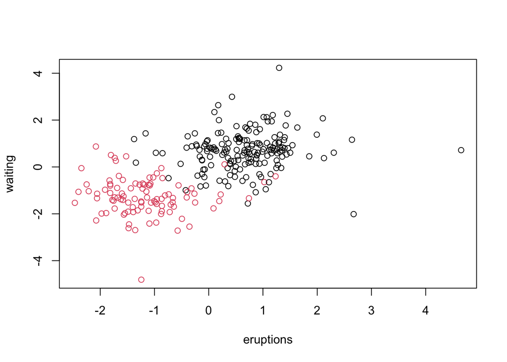

```r
# make it more challenging
set.seed(1)
faithful[,1] <- faithful[,1] + rt(n,df=5)/2
faithful[,2] <- faithful[,2] + rt(n,df=5)/2
plot(faithful[,1:2], col=faithful$cl)
```

```r
x <- faithful[,1:2]
y <- faithful[,3]
```

The first method-svm:

```r
# SVM with radial kernel
start1 = Sys.time()
svm_model <- train(x, y, method="svmRadial")
end1 = Sys.time()
out1 <- svm_model$results[rownames(svm_model$bestTune),]
kappa1 <- out1$Kappa
kappasd1 <- out1$KappaSD
time1 = end1-start1
```

So the code for random forest will not be executable here.

```r
#Random forest

#start2 = Sys.time()

#rf_model <- train(x, y, method="rf")

#end2 = Sys.time()

#out2 <- rf_model$results[rownames(rf_model$bestTune),]

#kappa2 <- out2$Kappa

#kappasd2 <- out2$KappaSD

#time2 = end2-start2
```

```r
# Gradient boosting machine
start3 = Sys.time()
boost3 <- train(x, y, method="gbm", verbose=FALSE)
end3 = Sys.time()
out3 <- boost3$results[rownames(boost3$bestTune),]
kappa3 <- out3$Kappa
kappasd3 <- out3$KappaSD
time3 = end3-start3
```

```r
df=data.frame(Method=c("svmRadial","gbm"), Kappa=c(kappa1,kappa3), KappaSD=c(kappasd1,  kappasd3), Time=c(time1,time3))
df
```

```
##      Method     Kappa    KappaSD          Time
## 1 svmRadial 0.9085400 0.03477917 2.361765 secs
## 2       gbm 0.8921195 0.03550474 1.586742 secs
```

Based on the results, we can see that SVM with radial kernel has the best Kappa.

Now, we make a `pointrange` plot, with the optimal Kappa and the SD for the optimal Kappa.

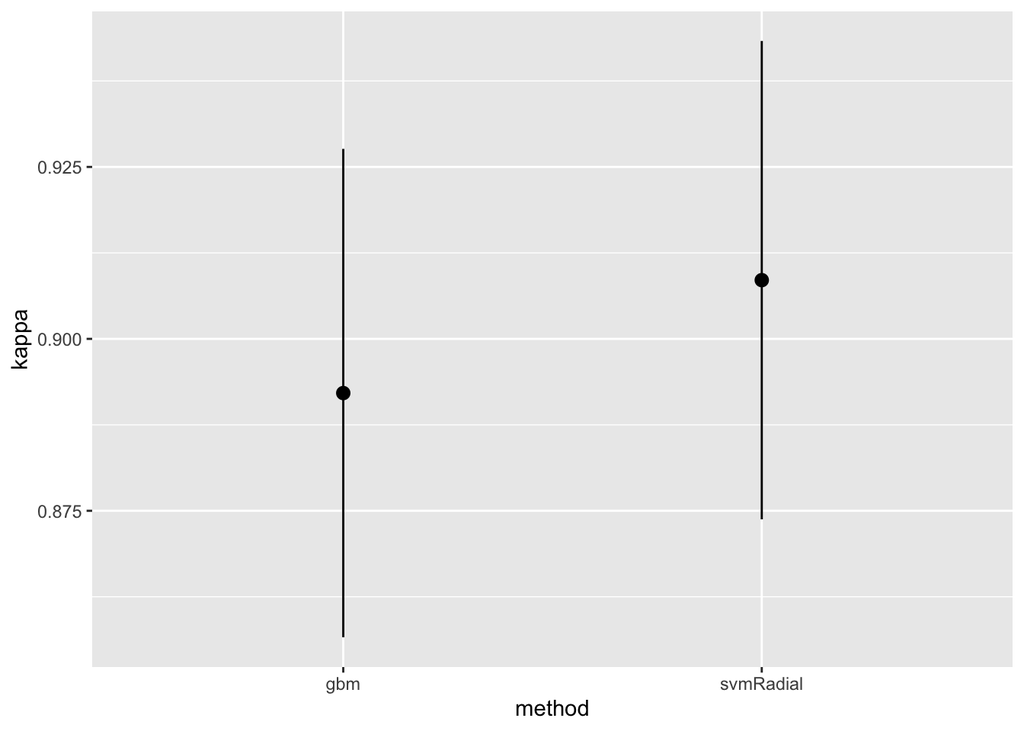

```r
r = 1
d=data.frame(method=c("svmRadial","gbm"), kappa=c(kappa1,kappa3), lower=c(kappa1-r*kappasd1,kappa3-r*kappasd3), upper=c(kappa1+r*kappasd1,kappa3+r*kappasd3))
ggplot() + geom_pointrange(data=d, mapping=aes(x=method, y=kappa, ymin=upper, ymax=lower))
```

From the final visualization `pointrange` plot, we can see that there is no big difference between the methods we discussed above.